# Statistical Approach for Pleiotropy Informed and Functional Annotation Tree Guided Prioritization of GWAS Results with `*multiGPATree*’ Package

Aastha Khatiwada<sup>1,#</sup>, Ayse Selen Yilmaz<sup>2</sup>, Bethany J. Wolf<sup>3</sup>, Maciej Pietrzak<sup>2</sup>, Dongjun Chung<sup>2,4</sup>

Source: vignettes/multiGPATree_vignette_html.Rmd

# 1 Overview

This vignette provides an introduction to the *`multiGPATree`* package. R package *`multiGPATree`* implements the *`multiGPATree`* method, a novel statistical approach to prioritizing risk-associated SNPs and the combinations of functional annotations related to one or more trait risk-associated SNPs. The *`multiGPATree`* approach employs a hierarchical model to integrate GWAS summary statistics for multiple traits and functional annotation information within a unified framework by combining an iterative procedure (EM algorithm (Dempster, Laird, and Rubin 1977)) and a multivariate decision tree algorithm (MVPART (De’Ath 2002)).

The package can be loaded with the command:

```r
> # install.packages("devtools")
> # library(devtools)
> # devtools::install_github("cran/mvpart")
> # library(mvpart)
> # devtools::install_github("asthakhatiwada/multiGPATree")
> library(multiGPATree)
```

This vignette is organized as follows. Section 2 discusses the data structure required to implement the *`multiGPATree`* method and section 3 describes the workflow to implement the *`multiGPATree`* method. Section 3.1 discusses how to fit a *`multiGPATree`* model, section 3.2 describes how to prune a large *`multiGPATree`* model, section 3.3 describes the *`multiGPATree`* model plot and functional annotation tree, and finally, section 3.4 explains command lines for association mapping and identification of combination of functional annotations for one or more traits using *`multiGPATree`*.

Please feel free to contact Aastha Khatiwada at *asthakhatiwada@gmail.com* to report bug or for any questions or suggestions regarding the *`multiGPATree`* package.

# 2 Data structure

In this vignette, we use the simulated data (*simdata*) provided in the package to fit the *`multiGPATree`* model for post-GWAS analysis. The simulated data includes information for three traits/phenotypes (P1, P2 and P3). In the simulated data, the number of SNPs and the number of functional annotations are set to $M=1000$ and $K=10$, respectively. The GWAS association $p$-values for the SNPs are stored in *simdata$gwasPval* and the binary functional annotation information for the SNPs are stored in *simdata$annMat*, respectively. The number of rows in *simdata$gwasPval* is assumed to be the same as the number of rows in *simdata$annMat* where the $i$-th ($i=1,...,M$) row of *gwasPval* and *annMat* correspond to the same SNPs.

```r
> data("simdata")
> class(simdata)
[1] "list"
> names(simdata)
[1] "annMat"   "gwasPval"
> dim(simdata$gwasPval)
[1] 1000    3
> dim(simdata$annMat)
[1] 1000   10
> head(simdata$gwasPval)
               P1         P2        P3
SNP_1 0.881475577 0.73590618 0.5570957
SNP_2 0.003366917 0.06501229 0.4555200
SNP_3 0.534409851 0.97024660 0.8244188
SNP_4 0.673207548 0.63491520 0.3282804
SNP_5 0.493856654 0.03222396 0.2064220
SNP_6 0.421566563 0.58832082 0.7860906
> head(simdata$annMat)
      A1 A2 A3 A4 A5 A6 A7 A8 A9 A10
SNP_1  1  0  0  0  0  0  0  0  0   0
SNP_2  1  0  0  0  0  0  0  0  1   0
SNP_3  1  0  0  0  0  0  1  0  0   0
SNP_4  1  0  0  0  0  0  1  0  1   0
SNP_5  1  0  0  0  0  0  0  0  0   0
SNP_6  1  0  0  0  0  0  0  1  1   0
```

# 3 Workflow

## 3.1 Fitting the multiGPATree Model

We are now ready to fit multi-GPA-Tree models using the GWAS $p$-value (*simdata$gwasPval*) and functional annotation data (*simdata$annMat*) described above. We can fit the multi-GPA-Tree models using the command below. Note that when there are 3 traits to analyze, the total number of GWAS pairs to be integrated is 3 (P1_P2, P1_P3 and P2_P3). The *`multiGPATree()`* function can integrate GWAS association p-values for multiple trait pairs simultaneously (in parallel), using the *`ncore`* parameter within the *`multiGPATree()`* function. We recommend users to increase the input for the *`ncore`* parameter as the number of GWAS traits in the data increases.

The object returned by the *`multiGPATree()`* function is of class *`multiGPATreeMethod`*. This object contains 3 elements: 1) *`fit`*, 2) *`gwasPval`* and 3) *`annMat`*. The object *`fit`* contains results pertaining to each GWAS pair that were analyzed, while *`gwasPval`* and *`annMat`* are the data matrices provided by the user. Each object in *`fit`* (P1_P2, P1_P3 and P2_P3) are of class *`multiGPATree`* and are input parameters for the *`prune()`*, *`plot()`*, *`leaf()`*, and *`assoc()`* functions described below.

```r
> fit.mGPATree <- multiGPATree(gwasPval = simdata$gwasPval,
+                             annMat = simdata$annMat,
+                             initAlpha = 0.1,
+                             cpTry = 0.005,
+                             ncore = 3)
> fit.mGPATree
Summary: multiGPATree model results (class: multiGPATree)
--------------------------------------------------
Data summary:
    Number of GWAS data: 3
    Number of Annotations: 10
    Number of SNPs: 1000
    Number of GWAS pairs: 3
--------------------------------------------------
> class(fit.mGPATree)
[1] "multiGPATreeMethod"
attr(,"package")
[1] "multiGPATree"
> #head(fit.mGPATree$gwasPval)
> #head(fit.mGPATree$annMat)
> names(fit.mGPATree@fit)
[1] "P1_P2" "P1_P3" "P2_P3"
```

## 3.2 Prunning the object of class *`multiGPATree`*

The *`prune()`* function will prune the objects of class *`multiGPATree`* using any *`cp`* value between 0 and 1 as shown below. As the *`cp`* value increases, the size of the tree decreases. We recommend pruning large trees to get results that are easier to interpret.

```r
> fit.mGPATree.pruned.p1p2 <- prune(fit.mGPATree@fit$P1_P2, cp = 0.20)
> fit.mGPATree.pruned.p1p2
Results summary: Functional annotation tree description for the selected GWAS pair
--------------------------------------------------
    Alpha estimates: 0.4454, 0.4129
       local FDR P1 local FDR P2                    Note
LEAF 1       0.8784       0.8867 No annotations selected
--------------------------------------------------
> # fit.mGPATree.pruned.p1p3 <- prune(fit.mGPATree@fit$P1_P3, cp = 0.20) #  PRUNING THE MULTIGPATREE MODEL RESULT FOR PHENOTYPES P1 AND P3
> # fit.mGPATree.pruned.p1p3
> # fit.mGPATree.pruned.p2p3 <- prune(fit.mGPATree@fit$P2_P3, cp = 0.20) #  PRUNING THE MULTIGPATREE MODEL RESULT FOR PHENOTYPES P2 AND P3
> # fit.mGPATree.pruned.p2p3
```

## 3.3 Functional annotation tree

The *`plot()`* function will plot the object of class *`multiGPATree`* and the *`leaf()`* function will provide information about the leaves (terminal nodes) in the tree for the object of class *`multiGPATree`* as shown below.

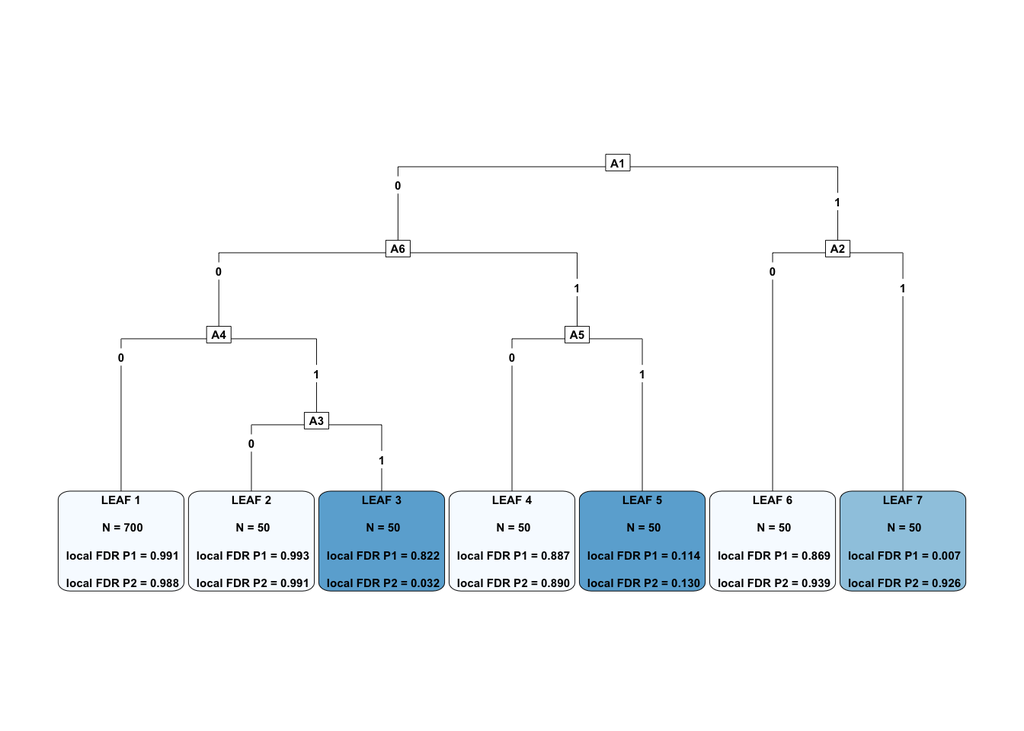

```r
> plot(fit.mGPATree@fit$P1_P2)
```

```r
> # plot(fit.mGPATree@fit$P1_P3) #  MULTIGPATREE MODEL PLOT FOR PHENOTYPES P1 AND P3
> # plot(fit.mGPATree@fit$P2_P3) #  MULTIGPATREE MODEL PLOT FOR PHENOTYPES P2 AND P3
```

```r
> leaf(fit.mGPATree@fit$P1_P2)
```

|  | local FDR P1 | local FDR P2 | A1 | A6 | A4 | A3 | A5 | A2 |
| --- | --- | --- | --- | --- | --- | --- | --- | --- |
| LEAF 1 | 0.990964 | 0.9876 | 0 | 0 | 0 | - | - | - |
| LEAF 2 | 0.993304 | 0.9914 | 0 | 0 | 1 | 0 | - | - |
| LEAF 3 | 0.822318 | 0.0315 | 0 | 0 | 1 | 1 | - | - |
| LEAF 4 | 0.887526 | 0.8901 | 0 | 1 | - | - | 0 | - |
| LEAF 5 | 0.114378 | 0.1295 | 0 | 1 | - | - | 1 | - |
| LEAF 6 | 0.869030 | 0.9390 | 1 | - | - | - | - | 0 |
| LEAF 7 | 0.007009 | 0.9257 | 1 | - | - | - | - | 1 |

```r
> # leaf(fit.mGPATree@fit$P1_P3) #  LEAF RELATED INFORMATION FOR PHENOTYPES P1 AND P3
> # leaf(fit.mGPATree@fit$P2_P3) #  LEAF RELATED INFORMATION FOR PHENOTYPES P2 AND P3
```

## 3.4 Association mapping

For each object of class *`multiGPATree`*, i.e., for each GWAS pair that is analyzed, we can make inferences about SNPs associated with the specific traits using the *`assoc()`* function by: $(1)$ prioritizing risk-associated SNPs for one or more traits, and (2) identifying the leaves of the *`multiGPATree`* model in which one or more trait risk-associated SNPs are located. For the *`P1_P2`* object of class *`multiGPATree`*, the *`assoc()`* function returns four columns. The first column contains binary values where 1 indicates that the SNP is marginally associated with the first trait (P1) and 0 indicates otherwise. Similarly, the second column contains binary values where 1 indicates that the SNP is marginally associated with the second trait (P2) and 0 indicates otherwise. The third column contains binary values where 1 indicates that the SNP is jointly associated with both traits (P1 and P2) and 0 indicates otherwise.Finally, the fourth column provides information regarding the leaf in which a SNP is located in the *`multiGPATree`* plot. The *`assoc()`* function allows both local (*`fdrControl="local"`*) and global FDR controls (*`fdrControl="global"`*) and users can set the threshold to be between 0 and 1 using the *`FDR`* argument.

For the simulated data, *`multiGPATree`* model identified $9$ SNPs to be jointly associated with traits P1 and P2 at the nominal global FDR level of $0.01$, all of which are located in leaf 5 which can be interpreted as the 9 risk SNPs being simultaneously annotated for both annotations $A5$ and $A6$. Similarly, *`multiGPATree`* model identified $68$ SNPs to be marginally associated with trait P1 at the nominal global FDR level of $0.01$. Of the $68$ SNPs, 50 SNPs are located in leaf 7 and are simultaneously annotated for $A1$ and $A2$ and 18 SNPs are located in leaf 5 and are simultaneously annotated for annotations $A5$ and $A6$. The following lines of code can be used to investigate association mapping and functional annotation tree for objects of class *`multiGPATree`*.

```r
>
> # ASSOCIATION MAPPING FOR PHENTYPES P1 AND P2
> assoc.mGPATree.p1p2 <- assoc(fit.mGPATree@fit$P1_P2,
+                              FDR = 0.01,
+                              fdrControl="global")
> head(assoc.mGPATree.p1p2)
```

|  | P1 | P2 | P1_P2 | leaf |
| --- | --- | --- | --- | --- |
| SNP_1 | 0 | 0 | 0 | LEAF 6 |
| SNP_2 | 0 | 0 | 0 | LEAF 6 |
| SNP_3 | 0 | 0 | 0 | LEAF 6 |
| SNP_4 | 0 | 0 | 0 | LEAF 6 |
| SNP_5 | 0 | 0 | 0 | LEAF 6 |
| SNP_6 | 0 | 0 | 0 | LEAF 6 |

```r
> table(assoc.mGPATree.p1p2$P1_P2)

  0   1
991   9
> table(assoc.mGPATree.p1p2$P1_P2, assoc.mGPATree.p1p2$leaf)

    LEAF 1 LEAF 2 LEAF 3 LEAF 4 LEAF 5 LEAF 6 LEAF 7
  0    700     50     50     50     41     50     50
  1      0      0      0      0      9      0      0
> table(assoc.mGPATree.p1p2$P1)

  0   1
932  68
> table(assoc.mGPATree.p1p2$P1, assoc.mGPATree.p1p2$leaf)

    LEAF 1 LEAF 2 LEAF 3 LEAF 4 LEAF 5 LEAF 6 LEAF 7
  0    700     50     50     50     32     50      0
  1      0      0      0      0     18      0     50
> table(assoc.mGPATree.p1p2$P2)

  0   1
960  40
> table(assoc.mGPATree.p1p2$P2, assoc.mGPATree.p1p2$leaf)

    LEAF 1 LEAF 2 LEAF 3 LEAF 4 LEAF 5 LEAF 6 LEAF 7
  0    700     50     22     50     38     50     50
  1      0      0     28      0     12      0      0
>
>
> # # ASSOCIATION MAPPING FOR PHENOTYPES P1 AND P3
> # assoc.mGPATree.p1p3 <- assoc(fit.mGPATree@fit$P1_P3,
> #                              FDR = 0.01,
> #                              fdrControl="global")
> # head(assoc.mGPATree.p1p3)
> # table(assoc.mGPATree.p1p3$P1_P3)
> # table(assoc.mGPATree.p1p3$P1_P3, assoc.mGPATree.p1p3$leaf)
> # table(assoc.mGPATree.p1p3$P1)
> # table(assoc.mGPATree.p1p3$P1, assoc.mGPATree.p1p3$leaf)
> # table(assoc.mGPATree.p1p3$P3)
> # table(assoc.mGPATree.p1p3$P3, assoc.mGPATree.p1p3$leaf)
> #
> # # ASSOCIATION MAPPING FOR PHENOTYPES P2 AND P3
> # assoc.mGPATree.p2p3 <- assoc(fit.mGPATree@fit$P2_P3,
> #                              FDR = 0.01,
> #                              fdrControl="global")
> # head(assoc.mGPATree.p2p3)
> # table(assoc.mGPATree.p2p3$P2_P3)
> # table(assoc.mGPATree.p2p3$P2_P3, assoc.mGPATree.p2p3$leaf)
> # table(assoc.mGPATree.p2p3$P2)
> # table(assoc.mGPATree.p2p3$P2, assoc.mGPATree.p2p3$leaf)
> # table(assoc.mGPATree.p2p3$P3)
> # table(assoc.mGPATree.p2p3$P3, assoc.mGPATree.p2p3$leaf)
>
```

# References

De’Ath, Glenn. 2002. “Multivariate Regression Trees: A New Technique for Modeling Species–Environment Relationships.” *Ecology* 83 (4): 1105–17.

Dempster, Arthur P, Nan M Laird, and Donald B Rubin. 1977. “Maximum Likelihood from Incomplete Data via the EM Algorithm.” *Journal of the Royal Statistical Society: Series B (Methodological)* 39 (1): 1–22.